# STAT4010: Final Review

Spring 2021

## Introduction

- We will quickly review some computational techniques and do an alternative version of A7
- We will also discuss some implementation strategies that can be quite useful
- Please attend the review lecture next week if you need tips on the theoretical materials

## Opening remark

- Not sure if you ever wonder why the tutorial note is named Karte
- Source: Black Jack (anime)
  - Doctor wants to give the best treatment condition on the current patient
  - Bayesian wants to give the best inference condition on the current data
  - They both look at the problem on a case by case basis

## Normalization

- Reasons
  - Computation, e.g., the unnormalized density will be 0 easily in computation (Ex4.1.2a)
  - Visualization, e.g., the unnormalized density plot will be ugly (Ex5.1.2c)
  - Data cleaning
- Techniques
  - `x/sum(x)`
    - Common for obtaining densities (because area under curve is 1)
  - `x/max(x)`
    - Common for visualization and data cleaning
  - `(x-mean(x))/sd(x)`
    - Common for (financial) data cleaning
  - `exp(log(x))`
    - Common for dealing with functions like `gamma()` and `beta()`
- Combine these techniques, e.g., `exp(log(x)-max(log(x)))`, for complex problems

## Random variable generation

- Discrete RV
  - Use `sample()` (Ex6.2.2)
  - Pmf, i.e., the argument `prob`, can be unnormalized; see the documentation in R
  - Whether it is discrete is determined by the support (Ex6.2.1)
- Continuous RV
  - Use built-in method first by checking conjugacy; see Ch2
  - Try inverse transform if there is formula online, e.g., [truncated normal](https://en.wikipedia.org/wiki/Truncated_normal_distribution#Generating_values_from_the_truncated_normal_distribution)
  - Try Metropolis–Hastings (MH) at the end
    - MH is more general than rejection sampling and importance sampling
- Set seed for reproducibility
- Non-built-in packages are usually not allowed unless they are used for visualization only
  - The requirement is usually stated in the question (Ex7.1.1b)

## Proposal in MH

- Support of proposal
  - Use discrete for discrete do not need MH for discrete RV in general
  - Use non-negative proposal for non-negative targets
    - For instance, we cannot use normal proposal for \(\sigma^2\) (Ex7.1.1b)
- Distribution of proposal
  - Choose one that you can simulate directly from
  - Simple choice: same as prior
    - Free of the problem with different supports
- Parameters in proposal
  - Usually set in way such that the mean is same as last realization and the sd is fixed as step size
  - Fixed parameter: independent MH; see Example 7.8
    - Performance critically depends on the proposal (cannot improve over time)
  - Variable step size: adaptive MCMC
    - Not covered in this course

## Posterior computation

- Use Gibbs if there are multiple target
  - Otherwise, we need to derive the joint posterior and simulate from it
- Implementation strategies
  - Initialization function
    - Input: data, hyperparameters, number of iterations, step size(s)
    - Output: environment (avoid passing arguments everywhere)
  - 1-step MH function
    - Perform MH-within-Gibbs if necessary
  - 1-step Gibbs function
    - Run 1-step MH and other direct generation steps
  - Different density functions
    - For computing acceptance probabilities
  - Diagnostics function
    - Input: environment, index of used sample
    - Output: convergence diagnostics, e.g., trace plot

## Improving the posterior sample

- Increase the number of iterations
- Tune the hyperparameters (if not fixed by the question)
- Tune the step size (if MH is used)
  - Use different step sizes for different targets
  - Change the proposal
- Diagnose the convergence numerically
  - Fixed-width analysis; see [Karte 9](https://hemanlmf.github.io/teaching/stat4010/2021S/Karte-9.html)
  - Effective sample size
- Thinning (use the sample every \(m\) iterations)

## Alternative version of A7

Let \(y_1, \ldots, y_n\) be \(n\) observations possibly from \(H\) different groups. The goal of this exercise is to learn how to classify them into \(H\) groups. Consider the following models: \[ \begin{aligned} \left[ y_i \mid z_i, \mu_{1:H}, \sigma^2_{1:H} \right] &\sim \mathrm{N}(\mu_{z_i}, \sigma^2_{z_i}), \qquad i=1, \ldots, n, \\ \left[ z_i \mid \theta \right] &\sim (1,\ldots,H)^\mathrm{T} \mathrm{Multi}_H(1, \theta),\qquad i=1, \ldots, n, \\ \left[ \mu_h \mid \sigma^2_h \right] &\sim \mathrm{N}(\eta, \kappa \sigma_h^2), \qquad h=1, \ldots, H, \\ \sigma^2_h &\sim b/\mathrm{Ga}(a), \qquad h=1, \ldots, H, \\ \theta &\sim \mathrm{Dir}_H((1/H, \ldots, 1/H)^\mathrm{T}), \end{aligned} \] where \(a,b, \kappa>0\), \(\eta\in\mathbb{R}\), and \(H\in\mathbb{Z}^+\) are some fixed non-random hyper-parameters. Note that the only modification that I made is \[ \left[ y_i \mid z_i, \mu_{1:H}, \sigma^2_{1:H} \right] \sim \mathrm{N}(\mu_{z_i}, \sigma^2_{z_i}), \] instead of truncated normal.

## Data generation

We generate \(y_1, \ldots, y_{100}\) from a mixture of three normal distributions with means \(-1, 0, 2\), standard deviation \(0.2, 0.9, 0.3\), and weights \(0.1, 0.55, 0.35\), respectively first.

```r
rMixNorm = function(n, mean, sd, weight){
  H = length(mean)
  I = sample(1:H, n, replace=TRUE, prob=weight)
  rnorm(n, mean[I], sd[I])
}
set.seed(4010)
n = 100
mean = c(-1, 0, 2)
sd = c(.2, .9, .3)
weight = c(.1, .55, .35)
y = rMixNorm(n, mean, sd, weight)
```

## Data generation

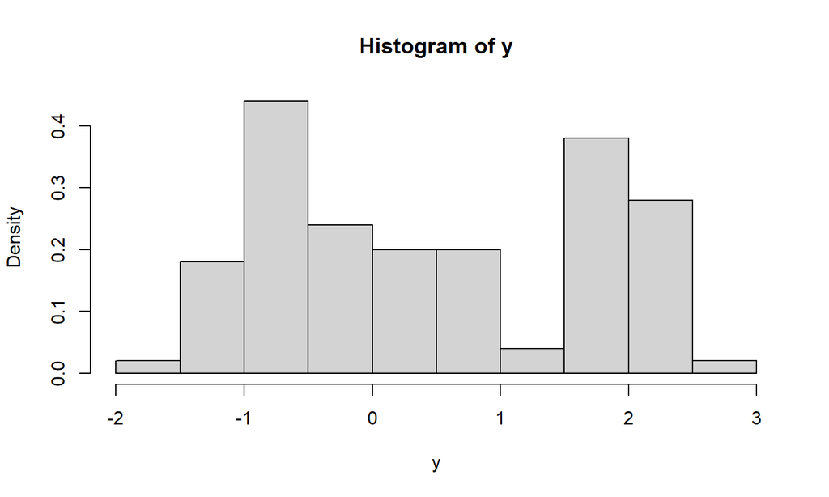

```r
hist(y, freq=FALSE)
```

## Posterior derivation

Since there are lots of parameters, it is more desirable to use the Gibbs sampler. We find the conditional density of \(\sigma^2_h\) for illustration. Note that \[ \begin{aligned} f(\sigma^2_h \mid \mu_h) &\propto f(\mu_h \mid \sigma^2_h) f(\sigma^2_h) \\ &\propto (\sigma^2_h)^{-\frac{1}{2}} \exp\left\{ -\frac{(\mu_h-\eta)^2}{2\kappa \sigma^2_h} \right\} (\sigma^2_h)^{-a-1} \exp\left( -\frac{b}{\sigma^2_h} \right) \mathbb{I}(\sigma^2_h>0) \\ &\sim \frac{b +(\mu_h-\eta)^2/(2\kappa)}{\mathrm{Ga}(a+1/2)}. \end{aligned} \]

## Posterior derivation

Let \(\Xi_h = \{i \in \{1,\ldots,n\}: z_i=h \}\) for \(h=1,\ldots,H\). By Example 2.12, \[ \begin{aligned} f(\sigma^2_h \mid y_{1:n}, z_{1:n}, \mu_{1:H}, \sigma_{-h}^2, \theta) &= f(\sigma^2_h \mid y_{\Xi_h}, z_{1:n}, \mu_h, \sigma_{-h}^2, \theta) \\ &\propto f(y_{\Xi_h} \mid \sigma^2_h, z_{1:n}, \mu_h, \sigma_{-h}^2, \theta) f(\sigma^2_h \mid z_{1:n}, \mu_h, \sigma_{-h}^2, \theta) \\ &= f(y_{\Xi_h} \mid \sigma^2_h, z_{1:n}, \mu_h) f(\sigma^2_h \mid \mu_h) \\ &\sim \frac{b +(\mu_h-\eta)^2/(2\kappa) +\sum_{i \in \Xi_h} (y_i-\mu_h)^2/2}{\mathrm{Ga}(a+1/2+|\Xi_h|/2)}, \end{aligned} \] where \(|\Xi_h| = \sum_{i=1}^n \mathbb{I}(z_i=h)\) denotes the cardinality of \(\Xi_h\).

Note: one of you asked why we can drop \(\sigma_{-h}^2\). See the explanation below: \[ \begin{aligned} & f(\sigma^2_h \mid y_{1:n}, z_{1:n}, \mu_{1:H}, \sigma_{-h}^2, \theta) \\ \propto{}& f(y_{\Xi_h} \mid \sigma^2_h, z_{1:n}, \mu_h, \theta) \underbrace{f(y_{-\Xi_h} \mid \sigma^2_{-h}, z_{1:n}, \mu_{-h}, \theta)}_{\textrm{does not include }\sigma_h^2} f(\sigma^2_h \mid z_{1:n}, \mu_h, \sigma_{-h}^2, \theta). \end{aligned} \]

## Posterior derivation

We state the other conditonal densities without proof. Note that some of them are not named in the real A7 and so you need to use MH. \[ \begin{aligned} f(\mu_h \mid y_{1:n}, z_{1:n}, \sigma^2_{1:H}, \theta) &\sim \mathrm{N}\left\{ \frac{(1/\kappa) \cdot \eta +|\Xi_h| \cdot \bar{y}_{\Xi_h}}{1/\kappa +|\Xi_h|}, \frac{\sigma^2_h}{1/\kappa +|\Xi_h|} \right\}, \\ f(\theta \mid y_{1:n}, z_{1:n}, \mu_{1:H}, \sigma^2_{1:H}) &\sim \mathrm{Dir}_H(q), \\ f(z_i \mid y_{1:n}, z_{-i}, \mu_{1:H}, \sigma^2_{1:H}, \theta) &\sim (1,\ldots,H)^\mathrm{T} \mathrm{Multi}_H(1, p_i), \end{aligned} \] where \[ \begin{aligned} \bar{y}_{\Xi_h} &= \frac{1}{|\Xi_h|} \sum_{i \in \Xi_h} y_i, \quad q = (1/H+|\Xi_1|, \ldots, 1/H+|\Xi_H|)^\mathrm{T}, \\ p_i &= (p_{i,1}, \ldots, p_{i,H})^\mathrm{T} \quad \mathrm{and} \quad p_{i,h} = \frac{\texttt{dnorm}(y_i, \mu_h, \sigma_h) \cdot \theta_h }{\sum_{h'=1}^H \texttt{dnorm}(y_i, \mu_{h'}, \sigma_{h'}) \cdot \theta_{h'}} \quad \mathrm{for} \quad h=1,\ldots,H. \end{aligned} \]

## MCMC implementation

First, we write a function to initialize the environment for our Gibbs.

```r
mcmc_init = function(nIter, ...){
  env = list2env(list(...))
  env$nIter = nIter
  with(env, {
    n = length(y)
    z = array(NA, dim=c(nIter+1,n))
    mu = sigma2 = theta = array(NA, dim=c(nIter+1,H))
    xi = vector("list", H)
    sigma20 = b/(a-1)
    q0 = rep(1/H, H)
    p = array(1/H, dim=c(n,H))
    mu[1,] = rnorm(H, eta, sqrt(kappa*sigma20))
    sigma2[1,] = 1/rgamma(H, a, b)
    theta[1,] = rDir(1, q0)
    z[1,] = vSample(1:H, p)
    iIter = 1
  })
  env
}
```

`rDir` and `vSample` are functions that can simulate from Dirichlet and multinomial. As a hint, you can read [Wikipedia](https://en.wikipedia.org/wiki/Dirichlet_distribution#Gamma_distribution) for direct generation of Dirichlet RVs.

## MCMC implementation

Second, we write a function to implement 1-step Gibbs:

```r
gibbs_step = function(env){
  with(env, {
    mu0 = mu[iIter,]
    for (h in 1:H)
      xi[[h]] = which(z[iIter,]==h)
    nXi = sapply(xi, length)
    for (h in 1:H) {
      i = xi[[h]]
      if (nXi[h] == 0) {
        sigma2[iIter+1,h] = rInvGa(1, a+1/2, b+(mu0[h]-eta)^2/2/kappa)
        mu[iIter+1,h] = rnorm(1, eta, sqrt(kappa*sigma2[iIter+1,h]))
      } else {
        sigma2[iIter+1,h] = rInvGa(1, a+(nXi[h]+1)/2,
                                 b+(mu0[h]-eta)^2/2/kappa+sum((y[i]-mu0[h])^2)/2)
        mu[iIter+1,h] = rnorm(1, (1/kappa*eta+nXi[h]*mean(y[i]))/(1/kappa+nXi[h]),
                            sqrt(sigma2[iIter+1,h]/(1/kappa+nXi[h])))
      }
    }
    q = q0 +nXi
    theta[iIter+1,] = rDir(1, q)
    for (h in 1:H)
      p[,h] = dnorm(y, mu[iIter+1,h], sqrt(sigma2[iIter+1,h]))*theta[iIter+1,h]
    z[iIter+1,] = vSample(1:H, p)
    iIter = iIter+1
  })
}
```

## MCMC implementation

Finally, we run and briefly check the posterior sample:

```r
mcmc_diag = function(env, iUse){
  par(mfrow=c(1,2))
  H = env$H
  # weight
  matplot(env$theta[iUse,], type="l", lty=1,
          main=bquote("Trace Plot of "*theta), ylab=bquote(theta))
  abline(h=weight, col="black", lwd=2, lty=1)
  hist(env$theta[iUse,], breaks=30, freq=FALSE,
       main=bquote("Histogram of "*theta), xlab=bquote(theta))
  abline(v=weight, col="black", lwd=2, lty=1)
}
nIter = 1e4
iUse = (.9*nIter):nIter +1
mcmc = mcmc_init(nIter, y=y, a=2, b=3, eta=1.5, kappa=5, H=4)
for (iIter in 1:nIter) {
  gibbs_step(mcmc)
}
mcmc_diag(mcmc, iUse)
```

## MCMC implementation

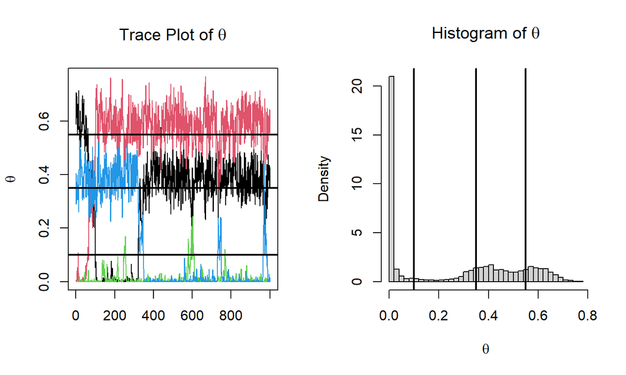

## General tips

- Answer **ALL** questions
  - Blank answer must score 0 (do not waste the chance!)
  - We give partial credit if you can show understanding of the materials
- The only thing that you **CANNOT** do is to communicate with others
- In other words, you can:
  - Use [WolframAlpha](https://www.wolframalpha.com/) to check algebra
  - Read [Stack Overflow](https://stackoverflow.com/) to debug R code
    - But you cannot ask questions there
  - Watch [YouTube](https://www.youtube.com/) video tutorials…
- Ask on Blackboard for clarification
- Remember to cite the source
- Submit on time

## All the best with the final!